# Electricity Forecast

Damian Wisniewski

2023-08-08

## Electricity Price Analysis and Forecast

In this workshop we want to build a model that will forecast monthly average price for August 2023 (For Western Norway). This will make it possible for us to give an estimate of the Governmental support scheme. We will use July 2023 as the test month to pick and compare different models. Later we will use our model to forecast August 2023.

# Data

```r
# Using Martin Jummu's github repository to get the data
elprices <- readr::read_csv(
  "https://raw.githubusercontent.com/martinju/stromstotte/master/data/database_nordpool_daily.csv")
```

Data is updated on daily basis and contains following columns: - area: Price regions (NO1, NO2, …, NO5) - date - price: Daily average price in NOK per kWh

Data preperation

```r
# Filter out prices for Western Norway
west_price <- elprices |>
  filter(area == 'NO5') |>  # NO5 is area representing Western Norway
  select(-area) |> # No need for area for our analysis
  as_tsibble(index = date) # Change object to a tsibble to make forecasting possible

# Create our test set - July 2023
july23 <- west_price |>
  filter(yearmonth(date) == yearmonth("Jul 2023"))

# Create our forecasting set - August 2023
august23 <- west_price |>
  filter(yearmonth(date) == yearmonth("Aug 2023"))

# Create our training set from months before July 2023
west_price <- west_price |>
  filter(yearmonth(date) < yearmonth("Jul 2023"))
```

## Exploratory Analysis

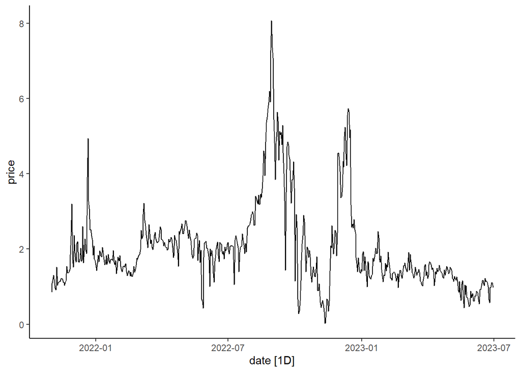

```r
# Plot of price
west_price |>
  autoplot(price)
```

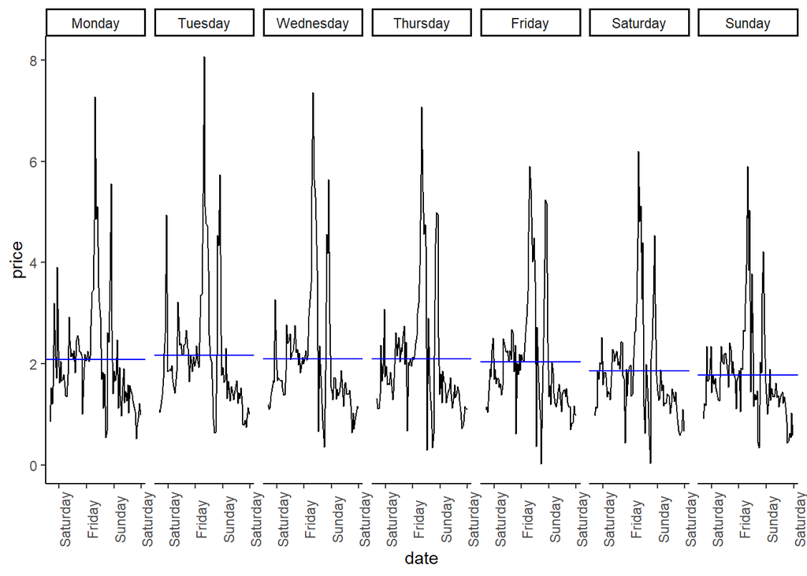

```r
#
west_price |>
  gg_subseries(price, period = "week")
```

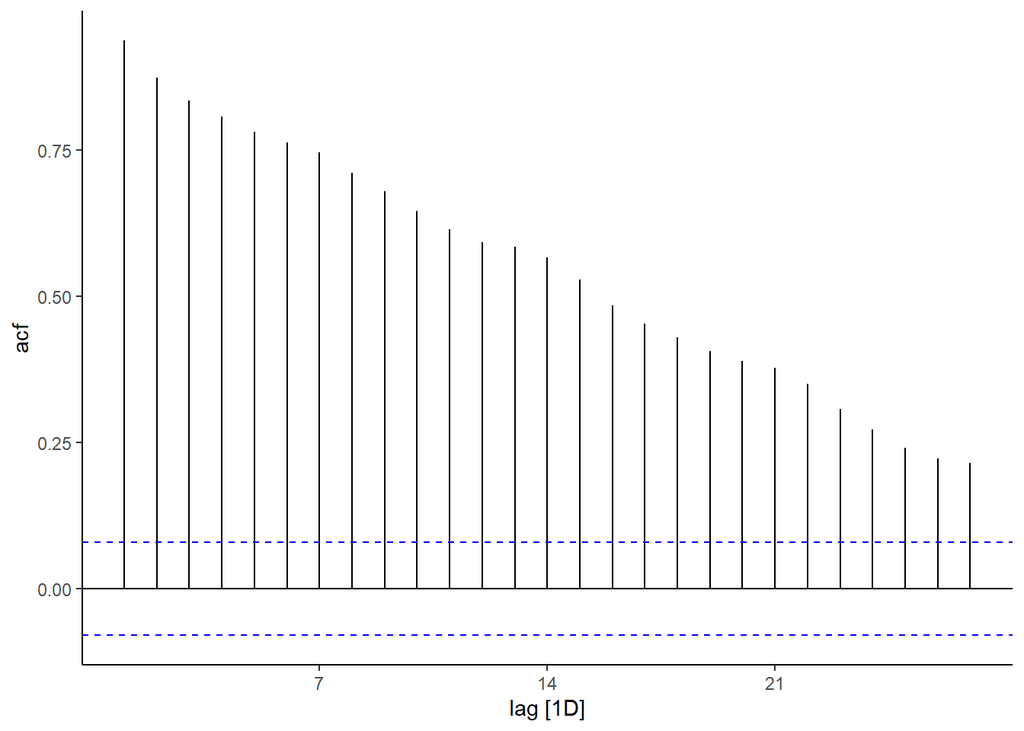

```r
west_price %>%
  ACF(price) %>%
  autoplot()
```

We can see a somewhat decreasing trend in the price level, as well as spikes around winter months. We can also see from subseries plot that prices for Saturday and Sundays tend to be little bit lower than other weekdays. We can also note on ACF plot that correlation between lags gets lower and lower. This can indicate that an ARIMA model can be good for our forcasting.

## Decomposition analysis

With daily observations, the methods used by official statistical agencies are not relevant as they only allow for monthly or quarterly data. Therefore in this workshop we will use STL method.

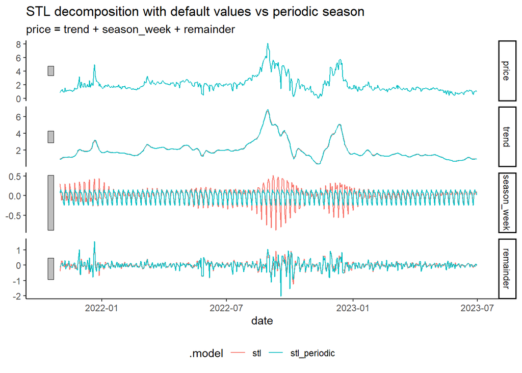

```r
west_price |>
  model(stl = STL(price ~ season(period = "week")),
        stl_periodic = STL(price ~ season(period = "week", window = "periodic"))) |>
  components() |>
  autoplot() +
  theme(legend.position = "bottom") +
  labs(title = "STL decomposition with default values vs periodic season")
```